[OHI-Northeast](http://www.ohi-northeast.org/) | [OHI Science](http://ohi-science.org) | [Citation policy](http://ohi-science.org/citation-policy/)

# OHI-Northeast: Trampling Pressure Data Prep

Compiled on Mon Oct 21 13:09:06 2019 by verstaen

# Summary

This code calculates the effects of beach trampling using population density along the coast as a proxy.

# Data

GeoTiff files were downloaded from https://sedac.ciesin.columbia.edu/data/set/usgrid-summary-file1-2010/metadata October 15th 2019

The data is at 1km2 resolution. Since we are only looking at total population that means #people/km2

Citation: Center for International Earth Science Information Network - CIESIN - Columbia University. 2017. U.S. Census Grids (Summary File 1), 2010. Palisades, NY: NASA Socioeconomic Data and Applications Center (SEDAC). https://doi.org/10.7927/H40Z716C. Accessed 16 October 2019.

# Methods

## Setup

```r
knitr::opts_chunk$set(fig.width = 10, fig.height = 8, fig.path = 'figs/', message = FALSE, warning = FALSE)

source('~/github/ne-prep/src/R/common.R')  ### an OHI-NE specific version of common.R

library(tidyverse)
library(ggplot2)
library(raster)
library(rgdal)
library(gdalUtils)
library(fasterize)

dir_git <- '~/github/ne-prep'
dir_anx <- file.path(dir_M, 'git-annex/neprep')
```

Read in the population tif files for each state, and then create one NE raster

```r
## read in all states rasters
northeast_rasters <- c(file.path(dir_anx, "_raw_data/NASA/usgrid_data_2010/geotiff/nypop10.tif"),
                    file.path(dir_anx, "_raw_data/NASA/usgrid_data_2010/geotiff/mepop10.tif"),
                    file.path(dir_anx, "_raw_data/NASA/usgrid_data_2010/geotiff/nhpop10.tif"),
                    file.path(dir_anx, "_raw_data/NASA/usgrid_data_2010/geotiff/ctpop10.tif"),
                    file.path(dir_anx, "_raw_data/NASA/usgrid_data_2010/geotiff/ripop10.tif"),
                    file.path(dir_anx, "_raw_data/NASA/usgrid_data_2010/geotiff/mapop10.tif"))

## combine all tif files into one
mosaic_rasters(gdalfile = northeast_rasters, dst_dataset = file.path(dir_anx, "prs_hab/northeast.tif"), of = "GTiff")
```

```
## [1] "/home/shares/ohi/git-annex/neprep/_raw_data/NASA/usgrid_data_2010/geotiff/nypop10.tif"
## [2] "/home/shares/ohi/git-annex/neprep/_raw_data/NASA/usgrid_data_2010/geotiff/mepop10.tif"
## [3] "/home/shares/ohi/git-annex/neprep/_raw_data/NASA/usgrid_data_2010/geotiff/nhpop10.tif"
## [4] "/home/shares/ohi/git-annex/neprep/_raw_data/NASA/usgrid_data_2010/geotiff/ctpop10.tif"
## [5] "/home/shares/ohi/git-annex/neprep/_raw_data/NASA/usgrid_data_2010/geotiff/ripop10.tif"
## [6] "/home/shares/ohi/git-annex/neprep/_raw_data/NASA/usgrid_data_2010/geotiff/mapop10.tif"
```

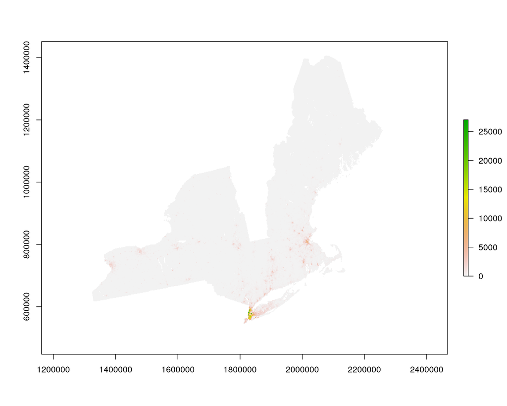

```r
## create one ne raster
northeast_rast <- raster::raster(file.path(dir_anx, "prs_hab/northeast.tif")) %>%
  projectRaster(crs = us_alb, progress="text")

## check it out!
plot(northeast_rast)
```

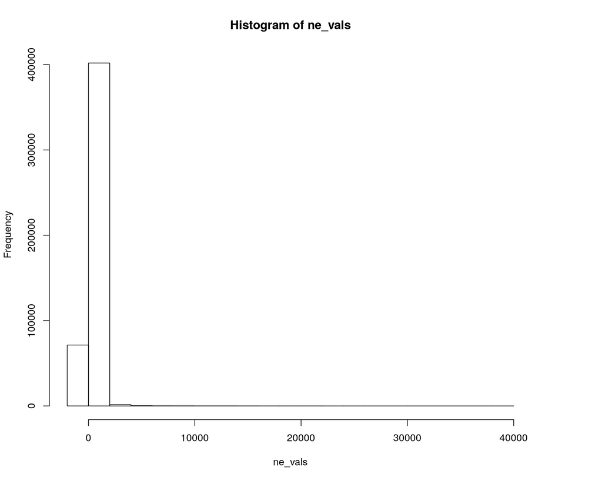

```r
ne_vals <-northeast_rast%>%
  getValues() %>%
  na.omit()

hist(ne_vals)
```

We are creating one giant coastal buffer that includes our coastline and 25 miles inland.

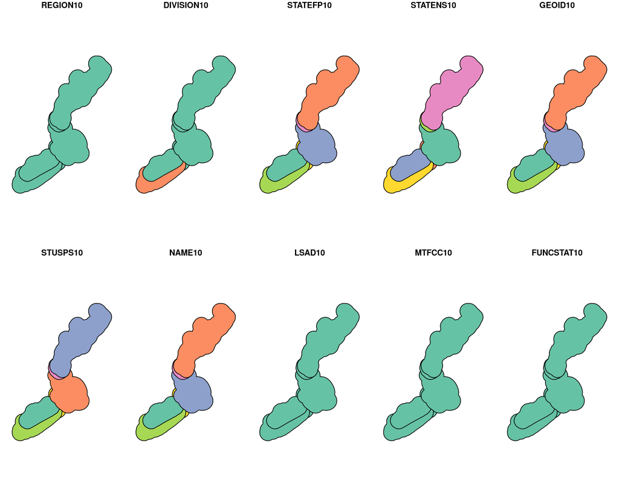

```r
## create a buffer 1 km along all state waters to get the beaches
buffer_1km_coastal <-  read_sf("~/github/ne-prep/spatial/shapefiles/state_waters.shp")  %>%
  st_transform(us_alb) %>%
  st_buffer(40233.6) %>%  ## data in meters; using a 25 miles buffer
 # st_union() %>%
  st_as_sf()

plot(buffer_1km_coastal)
```

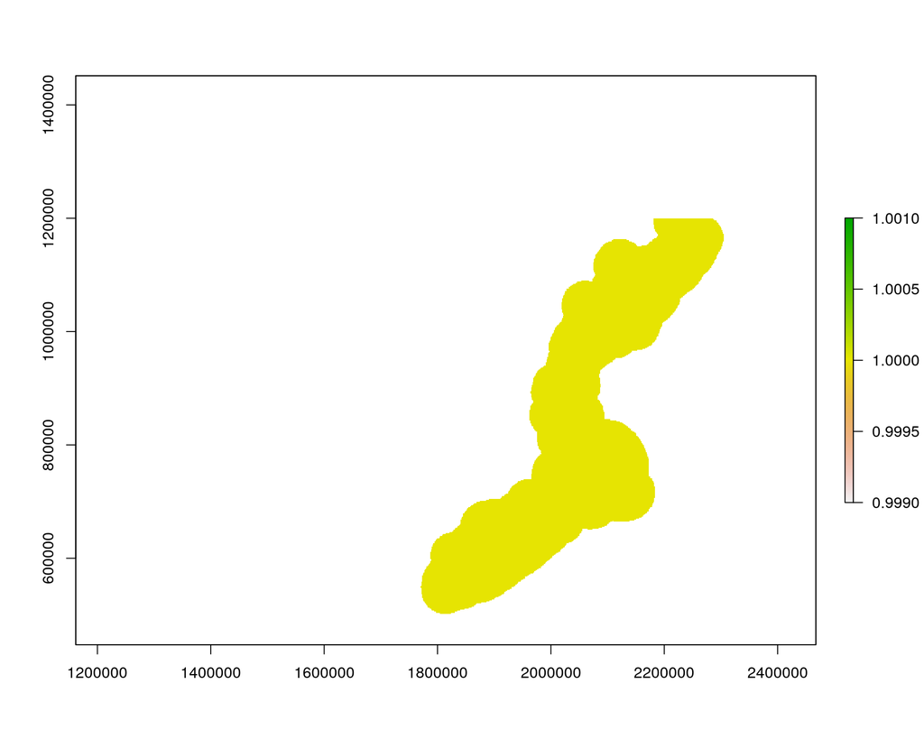

```r
## create blank raster for rasterizing
r <- raster(crs = us_alb, ne_ext, res = 1000)
r[r] <- 1

## convert to a raster
buffer_rast <- fasterize(buffer_1km_coastal, r) %>%
  raster::resample(northeast_rast, method = "ngb") ## match the resolution and extent
# the extent cuts off the top part of the buffer because that's out of Maine

plot(buffer_rast)
```

Now we want to keep only the population density data that falls into our 25 miles within the coastline raster

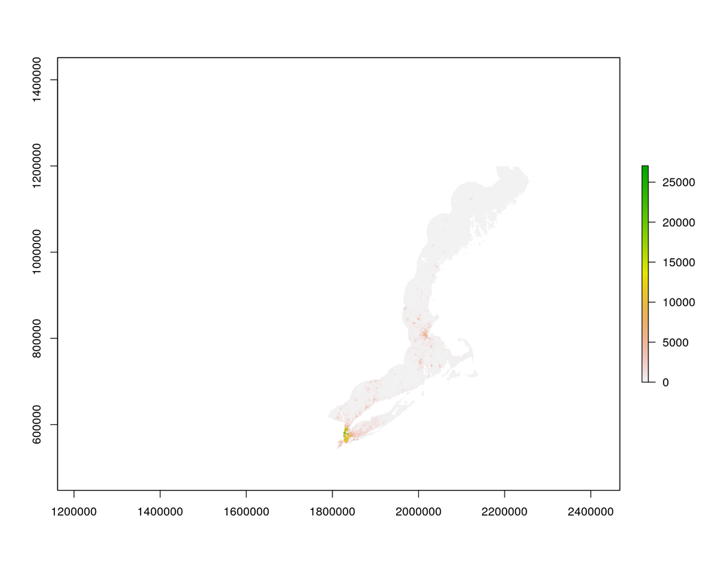

```r
## keep only the areas 1km along the shorelines
ne_pop_coast <- northeast_rast %>%
 raster::mask(buffer_rast) %>%
 calc(fun = function(x){ifelse(x < 0, 0, x)})  ## there are 3 negative numbers in this data for some reason (-77.9399, -0.2386, -0.0178)

plot(ne_pop_coast)
```

```r
summary(ne_pop_coast) # The max value is very large, this is because of NYC
```

```
##             layer
## Min.          0.0
## 1st Qu.       6.9
## Median       28.3
## 3rd Qu.     121.4
## Max.      38719.3
## NA's    1934205.0
```

Now we need a raster that has our region location information. To do so, we need to create a raster that has 25 mile buffer around each region.

```r
ne_states_zone <- read_sf("~/github/ne-prep/spatial/shapefiles/ne_ohi_rgns.shp")  %>%
  st_transform(us_alb) %>%
  filter(rgn_id != 3 & rgn_id != 2 & rgn_id != 4 & rgn_id != 1) %>%
  st_buffer(40233.6) %>%
  mutate(zone = rgn_id,
    zone = as.numeric(zone)) %>%
  select(zone, rgn_id, rgn_name)

ne_states_rast <- fasterize(ne_states_zone, r, field = "zone") %>%
  raster::resample(northeast_rast, method = "ngb") %>% ## match the resolution
  mask(buffer_rast)
```

Extract data for each region

```r
# extract data for each region:
pop_stats <- zonal(ne_pop_coast, ne_states_rast, fun="mean", na.rm=TRUE, progress="text")
pop_stats_2 <- data.frame(pop_stats) %>%
  rename(rgn_id = zone,
         avg_ppl_km2 = mean)
```

Calculate reference point We are using the reference point of 99.99% quantile. While this number is still high (because of NYC), it is an actually population density where people have survived

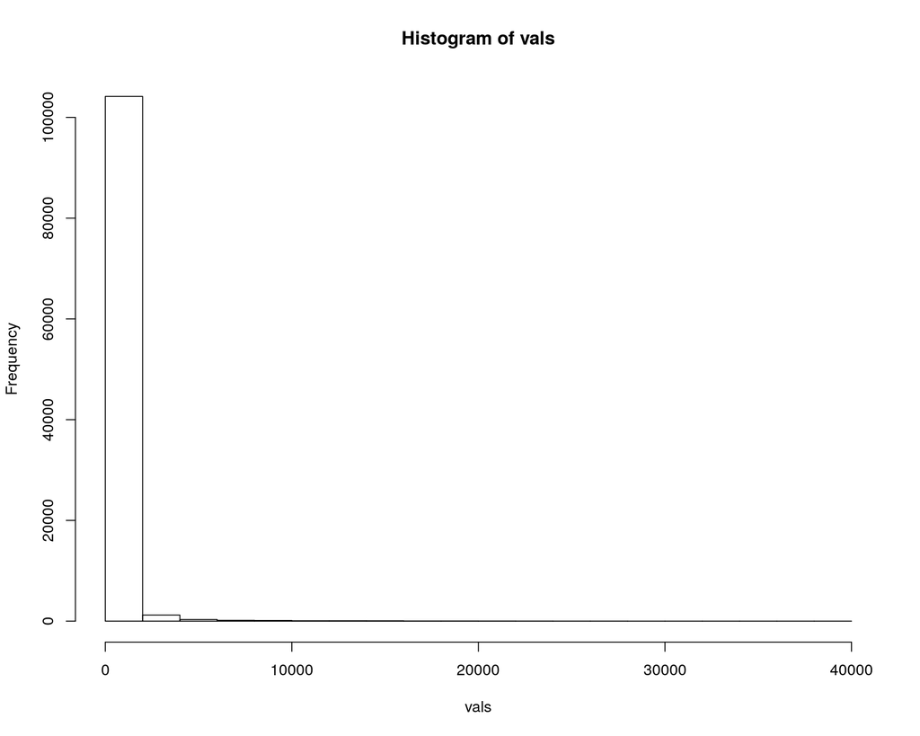

```r
vals <- ne_pop_coast %>%
  getValues() %>%
  na.omit()

hist(vals) ## very skewed
```

```r
max <- max(vals) #38719
ref_1 <- quantile(vals, 0.9999) #26188
ref_2 <- quantile(vals, 0.999) # 16199
ref_3 <- quantile(vals, 0.99) # 3582
ref_4 <- quantile(vals, 0.5) #28.3
```

Calculate pressure scores

```r
trampling <-pop_stats_2 %>%
  mutate(ref = ref_1,
         score_av = avg_ppl_km2/ref)
trampling
```

```
##   rgn_id avg_ppl_km2   ref score_av
## 1      5       185.7 26188 0.007093
## 2      6        22.5 26188 0.000858
## 3      7       582.0 26188 0.022224
## 4      8       158.4 26188 0.006049
## 5      9       112.9 26188 0.004311
## 6     10       886.8 26188 0.033863
## 7     11       169.1 26188 0.006457
```

Create a scores layer Creating a df to add on to the climate change scores to have the missing regions there

```r
miss_rgns <- tribble(
  ~rgn_id, ~rgn_name, ~score,
  3, "Gulf of Maine", NA,
  2, "Georges Bank", NA,
  4, "Mid-Atlantic Bight", NA,
  1, "Offshore", NA)
```

```r
prs_trampling <-trampling %>%
  select(rgn_id, score_av) %>%
  rename(score = score_av) %>%
  mutate(rgn_name = case_when(
    rgn_id == "6" ~ "Maine",
    rgn_id == "9" ~ "New Hampshire",
    rgn_id == "7" ~ "Massachusetts-North",
    rgn_id == "8" ~ "Massachusetts-South",
    rgn_id == "11" ~ "Rhode Island",
    rgn_id == "5" ~ "Connecticut",
    rgn_id == "10" ~ "New York")) %>%
  rbind(miss_rgns) %>%
  mutate(year = 2017)
```

Write scores to layers

```r
write.csv(prs_trampling, file.path(dir_calc, "layers/prs_trampling.csv"))
```